# TCGA MultiOmics Data Analysis

08/11/2015

## The dataset

### Retrieval

- TCGA normalized level 3 datasets for RNASeq and RPPA
- For tumor types breast cancer and ovary cancer

```r
library("RTCGAToolbox")
firehose_datasets = getFirehoseDatasets()
firehose_dates= getFirehoseRunningDates()
BRCA.dataset = getFirehoseData (dataset="BRCA", runDate=firehose_dates[1], RNAseq2_Gene_Norm = TRUE, RPPA=TRUE)
OV.dataset = getFirehoseData (dataset="OV", runDate=firehose_dates[1], RNAseq2_Gene_Norm = TRUE, RPPA=TRUE)
```

## The dataset

### Preprocessing

- Removed samples not having data for RNASeq and RPPA
- Removed variables for genes not matching with HGNC gene names
- Removed RPPA variables for antibodies matching the same gene, only the antibody with the maximum absolute average expression was conserved
- Scaling
- Removed variables with zero or near zero variance
- Removed variables with missing values
- Removed variables with correlation over 0.7

## The dataset

> Samples

407 BRCA + 201 ovary cancer samples

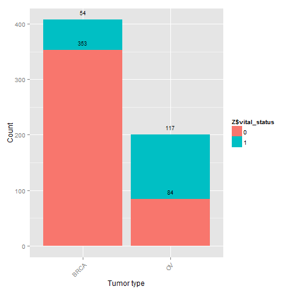

## The dataset

> Variables

12880 gene expression + 55 protein expression variables are far too many to plot…

## Principal component Analysis

> Gene expression

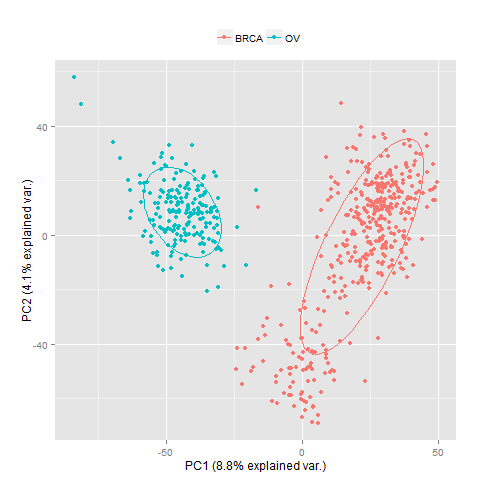

## Principal component Analysis

> Protein expression

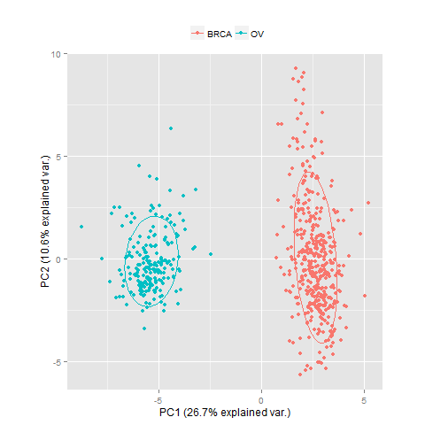

## Principal component Analysis

> Joint analysis

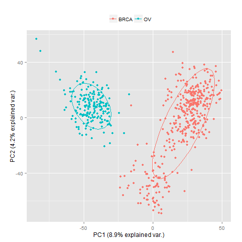

## Hierarchical clustering

> Joint analysis

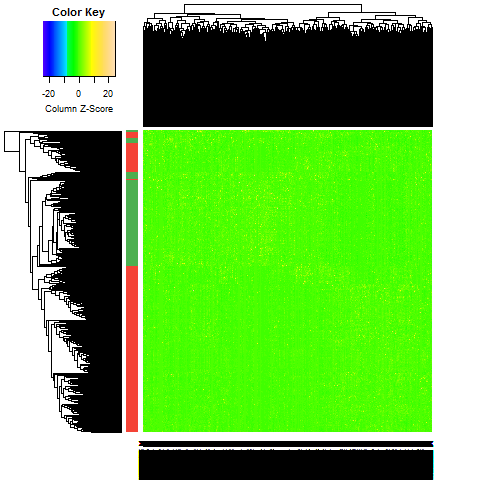

## Multiple Co-Inertia Analysis (MCIA)

> The 2 first PCs explain 34.05% and 11.55% of the variance

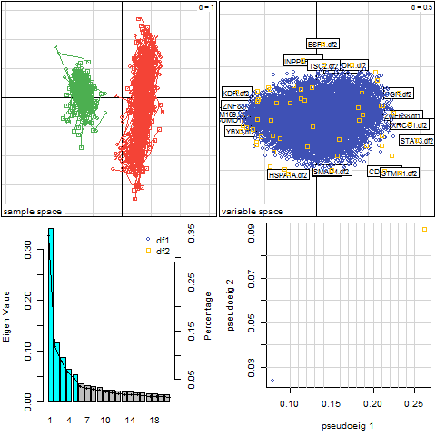

## Multiple Co-Inertia Analysis (MCIA)

> Labeled items are the top 100 variables

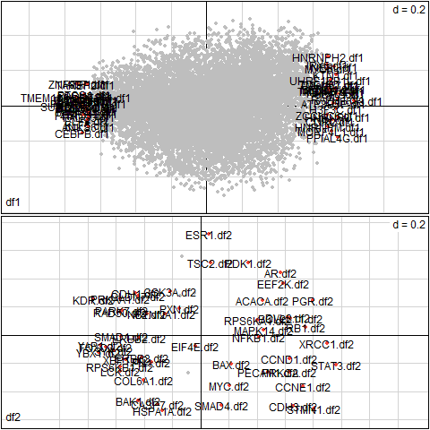

## sparse Least Square Regression (sPLS)

> Samples

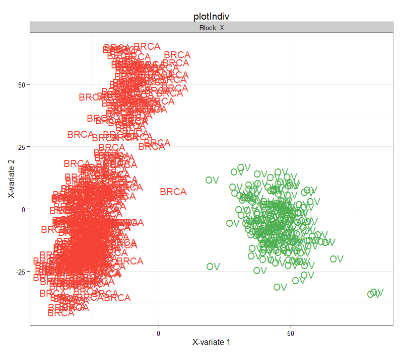

## sparse Least Square Regression (sPLS)

> Variables

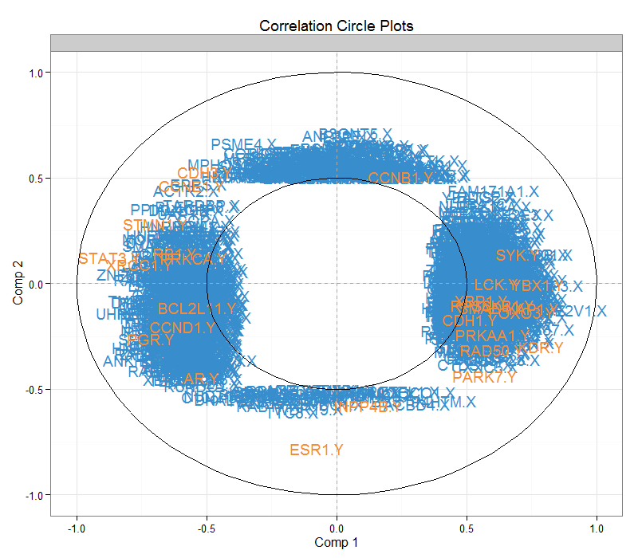

## sparse Least Square Regression (sPLS)

> Heatmap

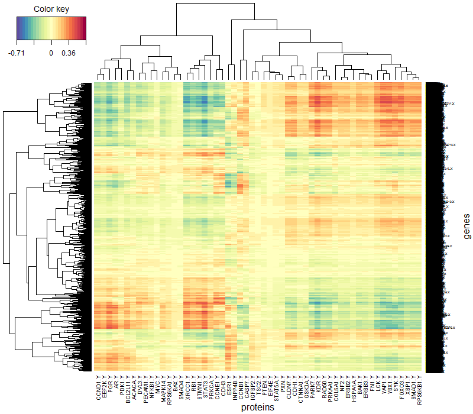

## sparse Least Square Regression (sPLS)

> Network

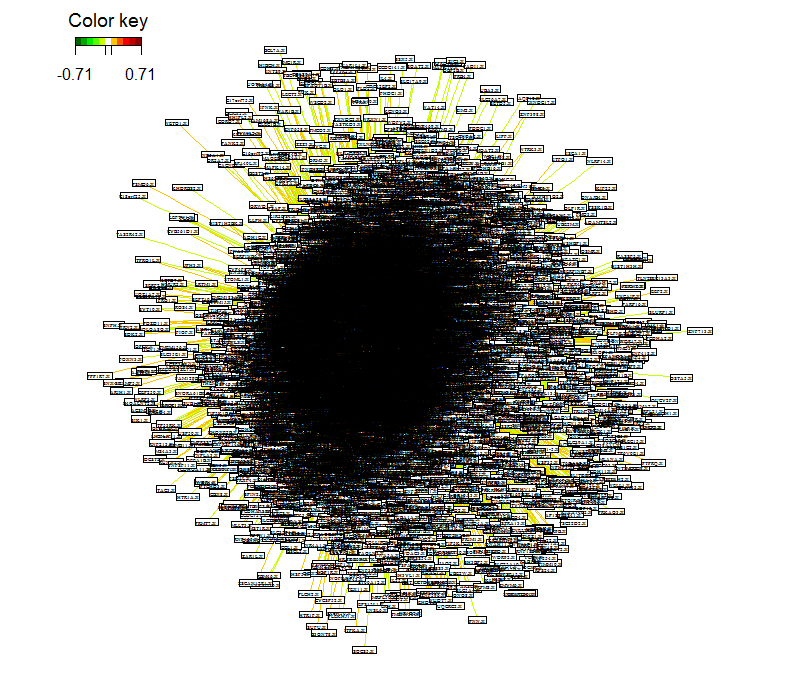

## Results

> Matches between MCIA and sPLS top 100 and known oncogenes and tumor supressor genes

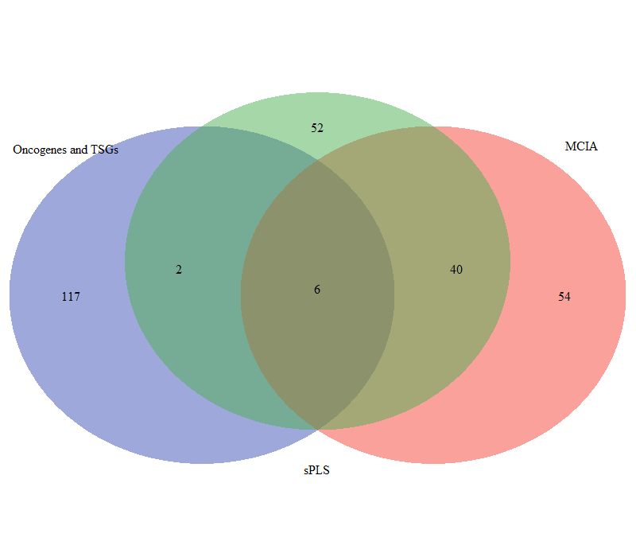

## Results

> Matches between MCIA and sPLS enriched pathways in Reactome

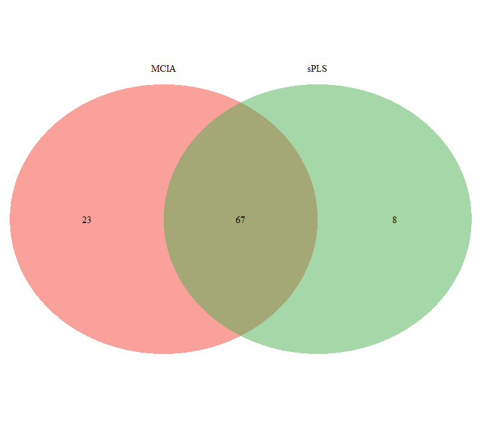

## Other methods to study

- Canonical Correlation Analysis
- Regularized Generalized CCA (error with dataset)
- Regularized CCA (long computation)
- CCA with Elastic Net (did not found implementation)
- Procrustes (pending)